# Practical 4 - Physiological Sensors

Alexandra Del Favero-Campbell

2024-06-10

There are 3-4 packages you will need to install for today’s practical: `install.packages(c("xgboost", "eegkit", "forecast", "tseries", "caret"))` apart from that everything else should already be available on your system.

If you are using a newer Mac you may have to also install [quartz](https://www.xquartz.org/) to have everything work (do this if you see errors about `X11` during install/execution).

I will endeavour to use explicit imports to make it clear where functions are coming from (functions without `library_name::` are part of base R or a function we’ve defined in this notebook).

## EEG Eye Detection Data

One of the most common types of medical sensor data (and one that we talked about during the lecture) are Electroencephalograms (EEGs).  
These measure mesoscale electrical signals (measured in microvolts) within the brain, which are indicative of a region of neuronal activity. Typically, EEGs involve an array of sensors (aka channels) placed on the scalp with a high degree of covariance between sensors.

As EEG data can be very large and unwieldy, we are going to use a relatively small/simple dataset today from [this paper](http://ehrai.com/su/pdf/aihls2013.pdf).

This dataset is a 117 second continuous EEG measurement collected from a single person with a device called a “Emotiv EEG Neuroheadset”. In combination with the EEG data collection, a camera was used to record whether person being recorded had their eyes open or closed. This was eye status was then manually annotated onto the EEG data with `1` indicated the eyes being closed and `0` the eyes being open. Measures microvoltages are listed in chronological order with the first measured value at the top of the dataframe.

Let’s parse the data directly from the `h2o` library’s (which we aren’t actually using directly) test data S3 bucket:

```r
eeg_url <- "https://h2o-public-test-data.s3.amazonaws.com/smalldata/eeg/eeg_eyestate_splits.csv"
eeg_data <- read.csv(eeg_url)

# add timestamp
Fs <- 117 / nrow(eeg_data)
eeg_data <- base::transform(eeg_data, ds = seq(0, 116.99999, by = Fs), eyeDetection = as.factor(eyeDetection))
print(table(eeg_data$eyeDetection))
```

```
##
##    0    1
## 8257 6723
```

```r
# split dataset into train, validate, test
eeg_train <- subset(eeg_data, split == 'train', select = -split)
print(table(eeg_train$eyeDetection))
```

```
##
##    0    1
## 4916 4072
```

```r
eeg_validate <- subset(eeg_data, split == 'valid', select = -split)
eeg_test <- subset(eeg_data, split == 'test', select = -split)
```

**0** Knowing the `eeg_data` contains 117 seconds of data, inspect the `eeg_data` dataframe and the code above too and determine how many samples per second were taken?  
Based on the code output from above, we know that there are a total of 14980 samples. The total duration of the EEG data is 117 seconds. Based on our calculations (shown below), there were approximately 128 samples per second taken.

```r
#Determining the Sampling Rate (samples per second)
# Calculate the number of rows
num_samples <- nrow(eeg_data)
num_samples #Total number of samples
```

```
## [1] 14980
```

```r
total_duration <- 117  # seconds
sampling_rate <- num_samples / total_duration
sampling_rate
```

```
## [1] 128.0342
```

**1** How many EEG electrodes/sensors were used?

There were 14 electrodes/sensors used. This is further confirmed when reviewing the paper where this data came from.

```r
colnames(eeg_data)
```

```
##  [1] "AF3"          "F7"           "F3"           "FC5"          "T7"
##  [6] "P7"           "O1"           "O2"           "P8"           "T8"
## [11] "FC6"          "F4"           "F8"           "AF4"          "eyeDetection"
## [16] "split"        "ds"
```

### Exploratory Data Analysis

Now that we have the dataset and some basic parameters let’s begin with the ever important/relevant exploratory data analysis.

First we should check there is no missing data!

```r
sum(is.na(eeg_data))
```

```
## [1] 0
```

Great, now we can start generating some plots to look at this data within the time-domain.

First we use `reshape2::melt()` to transform the `eeg_data` dataset from a wide format to a long format expected by `ggplot2`.

Specifically, this converts from “wide” where each electrode has its own column, to a “long” format, where each observation has its own row. This format is often more convenient for data analysis and visualization, especially when dealing with repeated measurements or time-series data.

We then use `ggplot2` to create a line plot of electrode intensities per sampling time, with the lines coloured by electrode, and the eye status annotated using dark grey blocks.

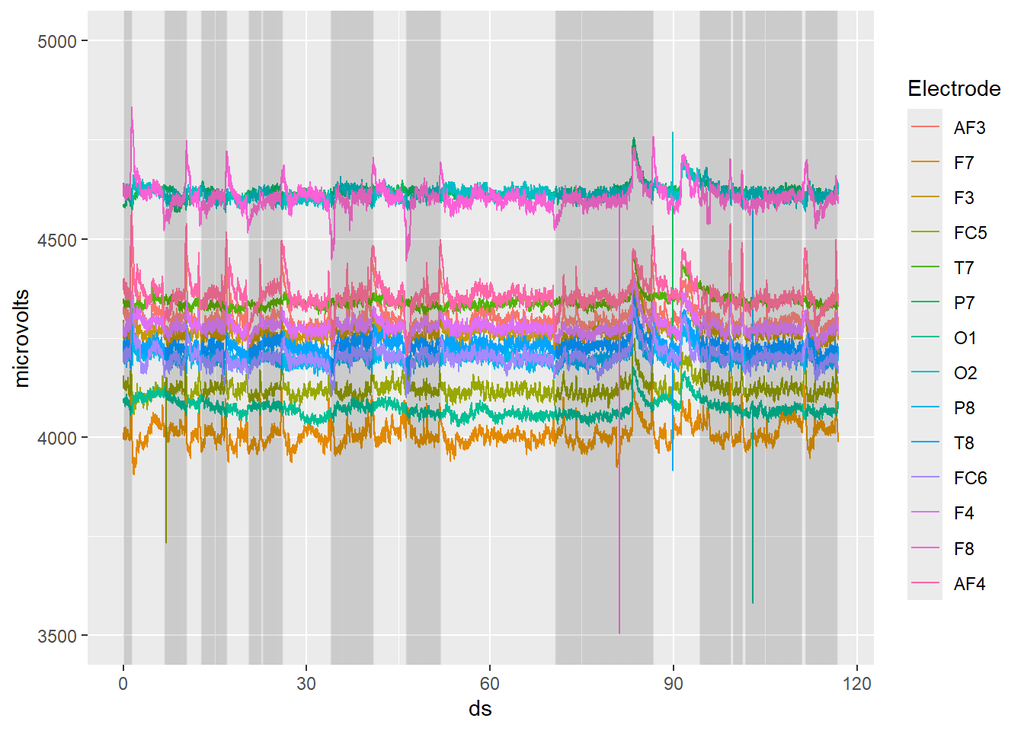

```r
melt <- reshape2::melt(eeg_data %>% dplyr::select(-split), id.vars=c("eyeDetection", "ds"), variable.name = "Electrode", value.name = "microvolts")


ggplot2::ggplot(melt, ggplot2::aes(x=ds, y=microvolts, color=Electrode)) +
  ggplot2::geom_line() +
  ggplot2::ylim(3500,5000) +
  ggplot2::geom_vline(ggplot2::aes(xintercept=ds), data=dplyr::filter(melt, eyeDetection==0), alpha=0.005)
```

**2** Do you see any obvious patterns between eyes being open (dark grey blocks in the plot) and the EEG intensities?

There are noticeable fluctuations in EEG intensities overtime, and the fluctuations appear to be more prominent in certain electrodes, especially as compared to others. If we take a further look at the patterns of each electrode in separate plots (see plots below), we confirm that different electrodes show varying levels of activity, with some having higher intensity and amounts of activity than others do. For example, some electrodes, such as F8 and AF3, show more pronounced changes when the eyes are closed. In other words, we see somewhat distinct increases in EEG intensity during periods when the eyes are closed; this could potentially suggest a correlation between the eyes closed state and increased EEG intensity in this particular electrode region. Moreover, similar to F8, certain electrodes, like AF3 and F3, show somewhat of an increase in EEG intensities when the eyes are closed too. However, the changes are less pronounced in comparison to F8. On the other hand, other electrodes, such as T7, P7, O1, and O2, do not show extremely significant differences between the eyes closed and the eyes opened states. They show more stable EEG intensity activity levels and display less distinctions between the closed eye state and the opened eye state. Furthermore, there seems to be a spike in EEG intensity just before and after the dark grey blocks.

In conclusion, there is a recognizable pattern suggesting that specific electrodes, such as F8 and AF3, display increased EEG activity when the eyes are in a closed state, potentially indicating that these corresponding specific regions of the brain become more active when visual inputs are reduced (i.e., when the eyes are closed). Furthermore, many other electrodes show way less variability, which suggests that they may be less sensitive to the state of the eye. It could also suggest that these less variable electrodes are recording from specific regions of the brain that are less affected by whether the eyes are open or not.

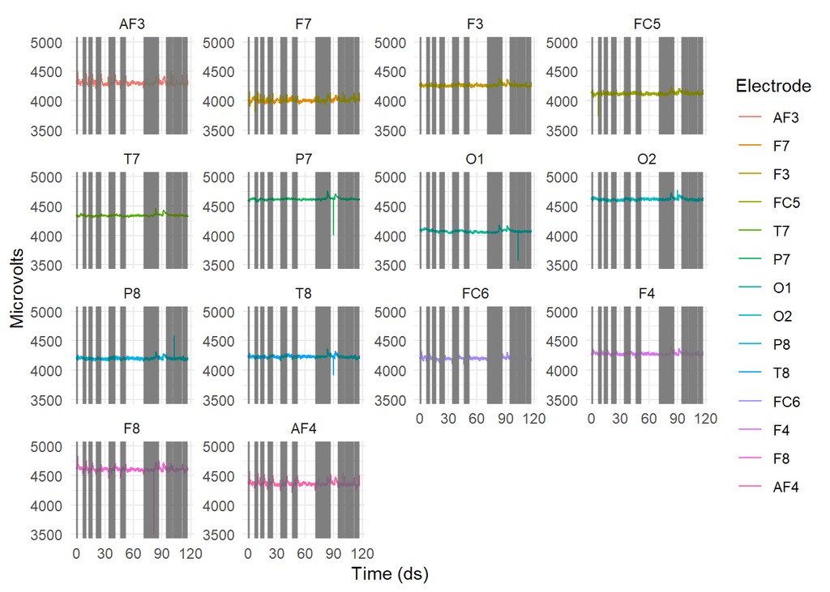

```r
# Load required libraries if not already loaded
library(dplyr)
library(ggplot2)
library(reshape2)  # Make sure reshape2 package is loaded for melt function

# Assuming eeg_data is your dataset containing EEG data

# Reshape data to long format
melt <- reshape2::melt(eeg_data %>% select(-split), id.vars = c("eyeDetection", "ds"), variable.name = "Electrode", value.name = "microvolts")

# Plot data separately for each electrode
ggplot(melt, aes(x = ds, y = microvolts, color = Electrode)) +
  geom_line() +
  ylim(3500, 5000) +  # Adjust ylim as needed
  geom_vline(aes(xintercept = ds), data = filter(melt, eyeDetection == 0), alpha = 0.005) +
  facet_wrap(~ Electrode, scales = "free_y") +  # Facet by Electrode
  labs(x = "Time (ds)", y = "Microvolts", color = "Electrode") +  # Adjust axis labels
  theme_minimal()
```

**3** Similarly, based on the distribution of eye open/close state over time to anticipate any temporal correlation between these states?

Overall, there does seem to maybe be a temporal correlation between these states. There seems to be a regular and periodic nature to the transitions that we see. The periods when the eyes are open occur in clusters for varying amounts of time, and the plot shows us that there are alternating periods between when the eyes are open and when they are closed. However, we do see that the clustering patterns of the eyes closed periods seem to be set in brief periods in which they tend to remain closed for brief periods of time before the eyes open again. Moreover, there seems to be more of a consistent alteration between the eyes being closed and then open throughout the 117 second duration period. Thus, temporally, it seems like there is a certain regularity to the transitions between when the eyes are open and when they close, which seems indicative of a possible cyclical or periodic behavioral pattern (e.g., due to potential natural blinking patterns or deliberate eye opening and closing in response to someone’s instructions or resting periods).

Let’s see if we can directly look at the distribution of EEG intensities and see how they related to eye status.

As there are a few extreme outliers in voltage we will use the `dplyr::filter` function to remove values outwith of 3750 to 50003. The function uses the `%in%` operator to check if each value of microvolts is within that range. The function also uses the `dplyr::mutate()` to change the type of the variable eyeDetection from numeric to a factor (R’s categorical variable type).

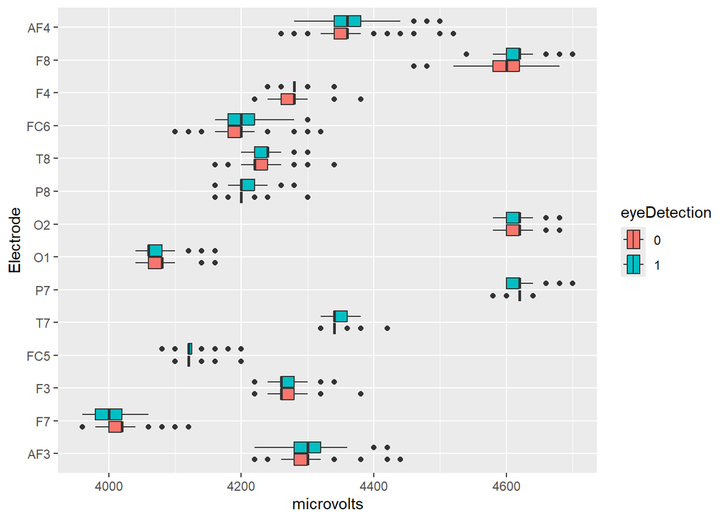

```r
melt_train <- reshape2::melt(eeg_train, id.vars=c("eyeDetection", "ds"), variable.name = "Electrode", value.name = "microvolts")

# filter huge outliers in voltage
filt_melt_train <- dplyr::filter(melt_train, microvolts %in% (3750:5000)) %>% dplyr::mutate(eyeDetection=as.factor(eyeDetection))

ggplot2::ggplot(filt_melt_train, ggplot2::aes(y=Electrode, x=microvolts, fill=eyeDetection)) + ggplot2::geom_boxplot()
```

Plots are great but sometimes so it is also useful to directly look at the summary statistics and how they related to eye status. We will do this by grouping the data based on eye status and electrode before calculating the statistics using the convenient `dplyr::summarise` function.

```r
filt_melt_train %>% dplyr::group_by(eyeDetection, Electrode) %>%
    dplyr::summarise(mean = mean(microvolts), median=median(microvolts), sd=sd(microvolts)) %>%
    dplyr::arrange(Electrode)
```

```
## # A tibble: 28 × 5
## # Groups:   eyeDetection [2]
##    eyeDetection Electrode  mean median    sd
##    <fct>        <fct>     <dbl>  <dbl> <dbl>
##  1 0            AF3       4294.   4300  35.4
##  2 1            AF3       4305.   4300  34.4
##  3 0            F7        4015.   4020  28.4
##  4 1            F7        4007.   4000  24.9
##  5 0            F3        4268.   4260  20.9
##  6 1            F3        4269.   4260  17.4
##  7 0            FC5       4124.   4120  17.3
##  8 1            FC5       4124.   4120  19.2
##  9 0            T7        4341.   4340  13.9
## 10 1            T7        4342.   4340  15.5
## # ℹ 18 more rows
```

**4** Based on these analyses are any electrodes consistently more intense or varied when eyes are open?

Most of the electrodes seem consistently the same in EEG intensity between eyes open status and eyes closed status, respective of the electrode. Although some electrodes may show slight differences in mean EEG intensities and variability (e.g., standard deviation), many (e.g., electrodes AF3, F3, FC5, T7, P8, T8, FC6, and F4) do not show what I would consider very significant differences or any difference at all.

However, there are a few that vary when it comes to the eyes being open versus the eyes being shut. For example, electrode F7 shows that the eyes being open has a slightly higher electrode intensity at around 4014.8 microvolts, whereas having the eyes closed showed an electrode intensity of around 4006.7 microvolts. It also shows less variability with the eyes closed (SD=24.86 microvolts) versus when the eyes were open (SD=28.38 microvolts); this indicates that the eyes being open may have slightly higher variability and EEG intensity. Electrodes O1 and P7 showed a similar mean between the eyes being open (around 4072.3 microvolts and 4617.86 microvolts, respectively) and the eyes being closed (around 4071.8 microvolts and 4617.61 microvolts, respectively), but more variability and wider spread when the eyes are closed (SD=24.29 and 19.13, respectively) versus when they were open (SD=16.93 and 11.18, respectively). Electrode F8 showed a slightly different trend with a slightly higher electrode intensity when the eyes were closed (mean of 4615.2 microvolts) than when the eyes were open (mean of 4595.7 microvolts). Electrode AF4 showed a slightly greater mean EEG intensity and less variability when the eyes were closed (4369.455±36.01 microvolts) than when they were open (4363.894±46.59 microvolts). Lastly, Electrode O2 showed slightly higher mean EEG intensity and more variability when the eyes were closed (4619.813±20.28 microvolts) as compared to when the eyes were opened (4615.71±17.46 microvolts).

Therefore, some varied in their patterns, but overall these variations were quite minimal. In terms of intensity, overall, most electrodes did not show too much of a significant difference in mean EEG intensities in terms of when the eyes were opened versus when the eyes were closed. However, some electrodes, such as electrode F8 and electrode AF4 did show somewhat higher EEG intensities when the eyes were closed. In terms of variability, there were quite a few electodes that showed more variability when the eyes were closed versus when they were open, including electrodes F8, O1, P7, and O2). There does not, however, seem to be a very consistent pattern across all of the electrodes that indicates that EEG readings are higher in intensity when the eyes are open versus when they are closed. However, we do see that potentially variability tends to maybe be higher when the eyes are closed, but only for certain electrodes.

#### Time-Related Trends

As it looks like there may be a temporal pattern in the data we should investigate how it changes over time.

First we will do a statistical test for stationarity:

```r
apply(eeg_train, 2, tseries::adf.test)
```

```
## $AF3
##
##  Augmented Dickey-Fuller Test
##
## data:  newX[, i]
## Dickey-Fuller = -20.669, Lag order = 20, p-value = 0.01
## alternative hypothesis: stationary
##
##
## $F7
##
##  Augmented Dickey-Fuller Test
##
## data:  newX[, i]
## Dickey-Fuller = -12.079, Lag order = 20, p-value = 0.01
## alternative hypothesis: stationary
##
##
## $F3
##
##  Augmented Dickey-Fuller Test
##
## data:  newX[, i]
## Dickey-Fuller = -11.587, Lag order = 20, p-value = 0.01
## alternative hypothesis: stationary
##
##
## $FC5
##
##  Augmented Dickey-Fuller Test
##
## data:  newX[, i]
## Dickey-Fuller = -11.122, Lag order = 20, p-value = 0.01
## alternative hypothesis: stationary
##
##
## $T7
##
##  Augmented Dickey-Fuller Test
##
```

[output cut: 87 more lines]

```
##
##  Augmented Dickey-Fuller Test
##
## data:  newX[, i]
## Dickey-Fuller = -4.8699, Lag order = 20, p-value = 0.01
## alternative hypothesis: stationary
##
##
## $ds
##
##  Augmented Dickey-Fuller Test
##
## data:  newX[, i]
## Dickey-Fuller = -2.4104, Lag order = 20, p-value = 0.4045
## alternative hypothesis: stationary
```

**5** What is stationarity?

The idea of “stationarity” asks the quesiton of whether the given time series that you are working with actually shows change overtime in a meaningful way. Short-term fluctuations (e.g., seasonality) can happen, but if what you are seeing is consistent, for example every year or every breath exhalation, and you see so really long-term trends or irregular cycling component, then you are probably dealing with a stationary signal as time does not really seem to affect the underlying probability distribution of that given signal.

Put simply, stationarity means that the statistical properties of a process that is generating a time series does not change over time. Technically, a signal is defined as “stationary” if that signal’s statistical characteristics do *not* vary over time. This means, consequently, that things such as means and variance also do not change over time for that signal. A potential example to try to explain this is if we imagine a reservoir where inflow and outflow are balanced, which allows it to maintain a constant average water level over time. If we are measuring the water level of that reservoir overtime, we may see it fluctuate over time slightly due to things like waves and minor variations in flow; however, the overall statistical properties, such as mean and variance, are very likely to remain stable, making this signal a good example of at least weak stationarity. Conversely, nonstationarity basically happens when the statistical characteristics of a signal *do* change with time. To clarify, stationarity does not mean that, that given series does not change over time; it just means that the *way* in which it changes does not itself change over time (Affek, 2019). If we think about it kind of like an algebraic linear function, the linear function changes as the variable, x, grows; however, the *way* in which it grows and changes remains constant in the idea that it has a constant slope or one value that captures that rate of change over time (Affek, 2019).

It is important to check a time series for stationarity, particularly before applying statistical and machine learning models because there are many models that have the assumption that the input data is stationary. Thus, if you were to input non-stationary data, it could lead to some misleading results and poor modeling performance.

**6** Why are we interested in stationarity? What do the results of these tests tell us? (ignoring the lack of multiple comparison correction…)

As mentioned previously, we are interested in stationarity within a time series context because its implications in a time series analysis are critical when it comes to accurate modeling and predicting. Many time series models (e.g., AutoRegressive Integrated Moving Average (ARIMA)) assume that the data you are using is stationary. This also true when it comes to thinking about predicting and forecasting. Accurate forecasting usually relies on the assumption of stationarity, as non-stationay data often leads to inconsistent and biased predictions. Since stationarity means statistical properties are constant overtime, past data is able to be used to predict future data. This allows for more reliable statistical inferencing. Thus, if the data you are using in these sorts of models is actually not stationary, then you are using an inappropriate model for your data or you may need to transform you data before using such a model to achieve some semblance of stationarity first.

With regard to the second portion of this question, the results of our tests are basically helping us check for stationarity in a time series. The Augmented Dickey-Fuller (ADF) test that we performed basically tells us that the electrodes (i.e., AF3, F7, F3, FC5, T7, P7, O1, O2, P8, T8, FC6, F4, F8, and AF4) and the eyeDetection variable all yielded a p-value of 0.01, which indicates that these time series are stationary. This essentially means that their statistical properties, such as mean and variance, do not change over time, which is perfect for time series modeling and forecasting. However, the ADF test also found that the ds variable has a p-value of 0.4045, which is indicative of nonstationarity. This basically means that the statistical properties of the ds variable change over time, potentially suggesting the presence of seasonality and trends. This variable, thus, may require some additional preprocessing and transforming, using something like differencing, to make it more stationary before it is able to be used for time series modeling.

Then we may want to visually explore patterns of autocorrelation (previous values predict future ones) and cross-correlation (correlation across channels over time) using `forecast::ggAcf` function.

The ACF plot displays the cross- and auto-correlation values for different lags (i.e., time delayed versions of each electrode’s voltage timeseries) in the dataset. It helps identify any significant correlations between channels and observations at different time points. Positive autocorrelation indicates that the increase in voltage observed in a given time-interval leads to a proportionate increase in the lagged time interval as well. Negative autocorrelation indicates the opposite!

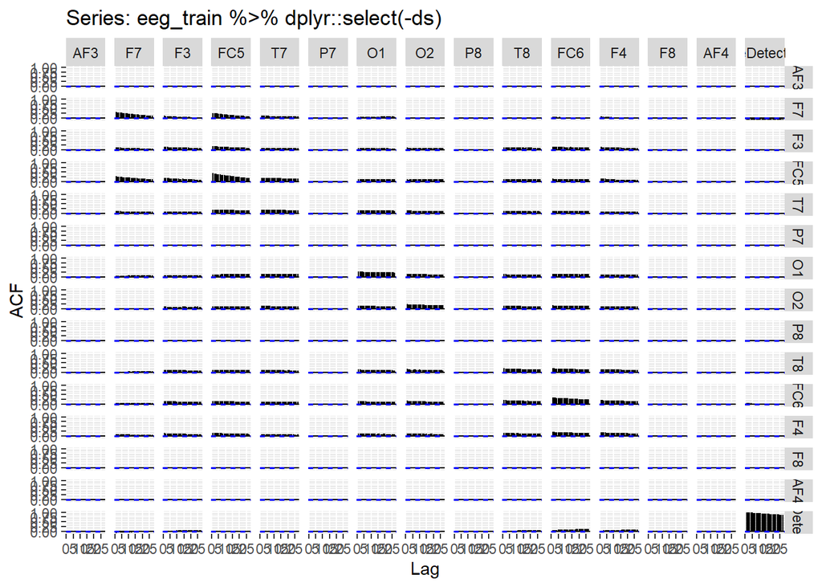

```r
forecast::ggAcf(eeg_train %>% dplyr::select(-ds))
```

**7** Do any fields show signs of strong autocorrelation (diagonal plots)? Do any pairs of fields show signs of cross-correlation? Provide examples.

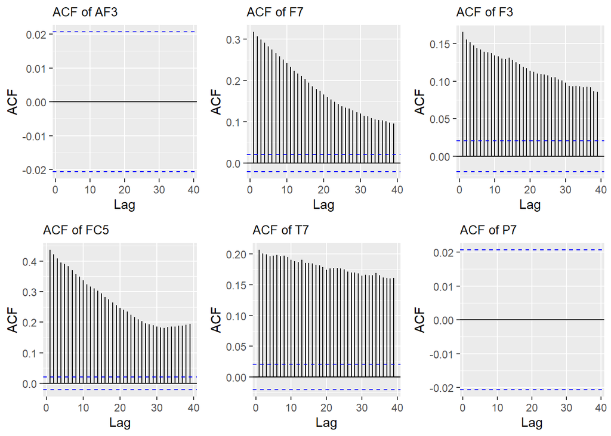

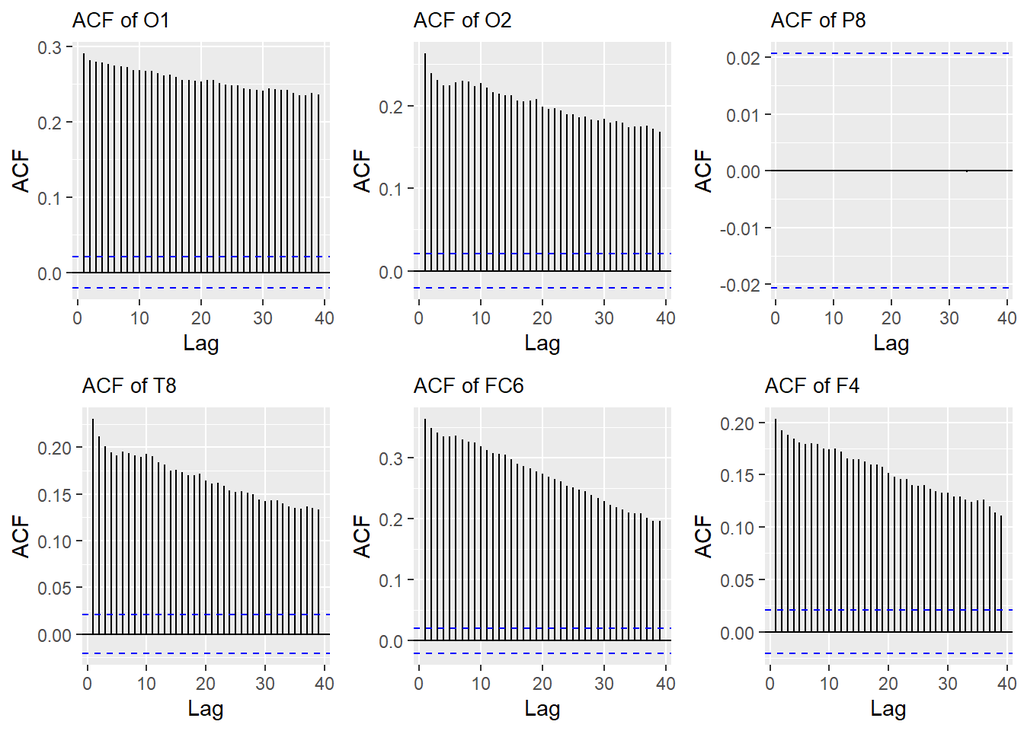

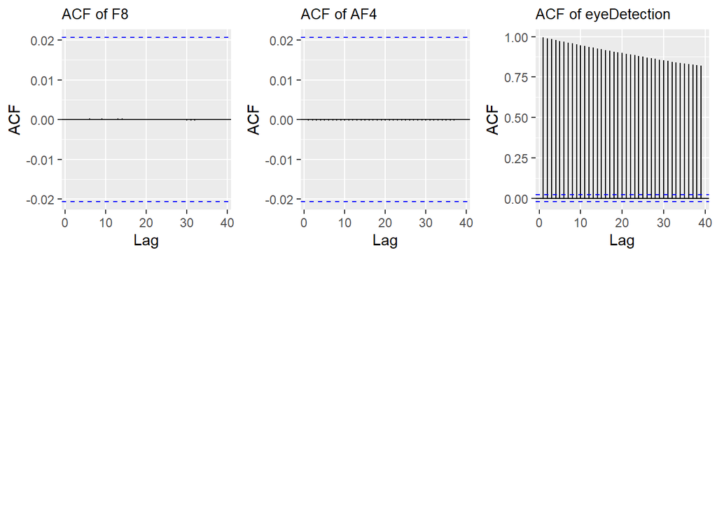

```r
# Load required libraries
library(forecast)
library(ggplot2)
library(dplyr)
library(gridExtra)
# Select columns excluding 'ds'
eeg_train_selected <- eeg_train %>% select(-ds)

# Create a list to store the plots
acf_plots <- list()

# Loop over each column to create individual ACF plots
for (column_name in colnames(eeg_train_selected)) {
  # Extract the column data
  column_data <- eeg_train_selected[[column_name]]

  # Create the ACF plot
  acf_plot <- ggAcf(column_data) +
    ggtitle(paste("ACF of", column_name)) +
    theme(plot.title = element_text(size = 10))  # Adjust title size here

  # Add the plot to the list
  acf_plots[[length(acf_plots) + 1]] <- acf_plot
}

# Print plots in pages of 6
plot_pages <- split(acf_plots, ceiling(seq_along(acf_plots) / 6))

for (page in plot_pages) {
  do.call("grid.arrange", c(page, ncol = 3, nrow = 2))
}
```

The ACF plot for AF3 shows that all autocorrelations are pretty close to 0 and show no significant spikes, all falling well within the 95% confidence bounds, indicating no significant autocorrelation. The same can be said of the ACF plots for electrodes AF4, P7, P8, and F8. The ACF plots for eyeDetection and F3 show significant autocorrelations at several lags, staying above the confidence bounds for multiple lags. This indicates strong autocorrelation. The same can be said for electrodes F4, F7, FC5, O2, O1, FC6, T7, and T8. Thus, the variables that seem to show strong autocorrelation are eyeDetection and electrodes F3, F4, F7, FC5, O2, O1, FC6, T7, and T8.

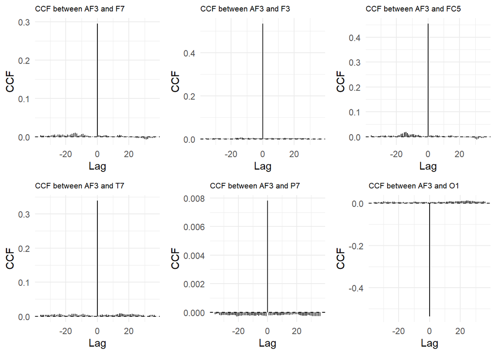

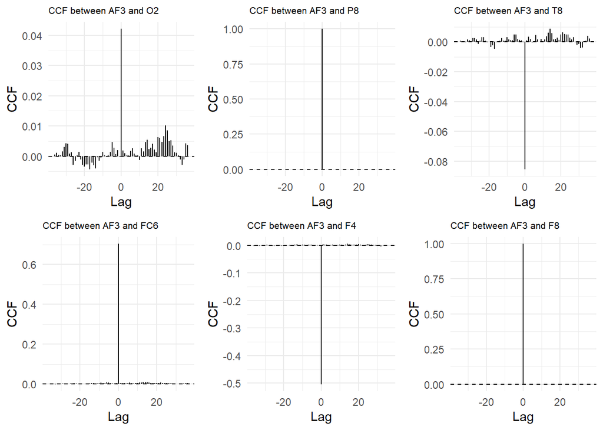

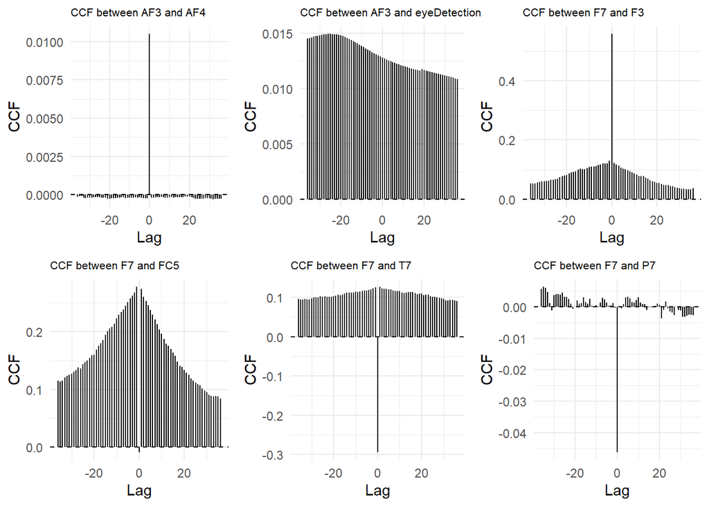

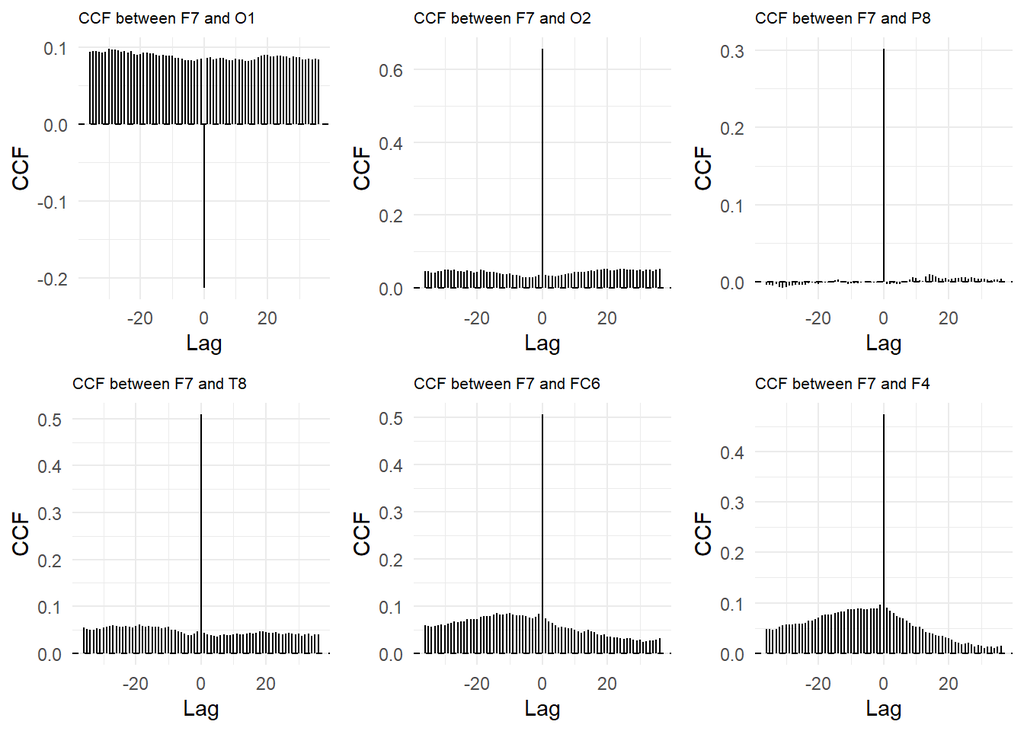

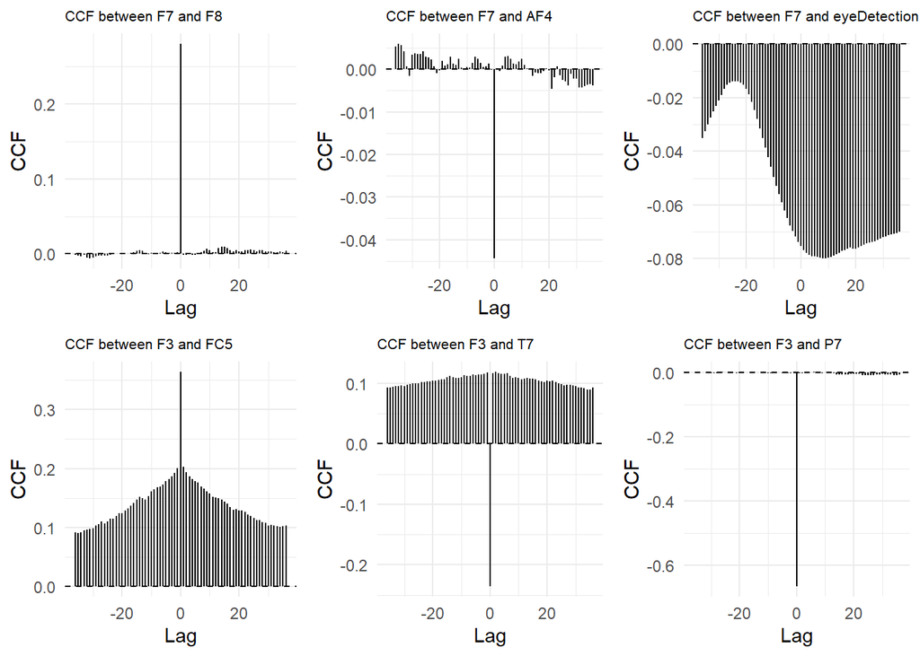

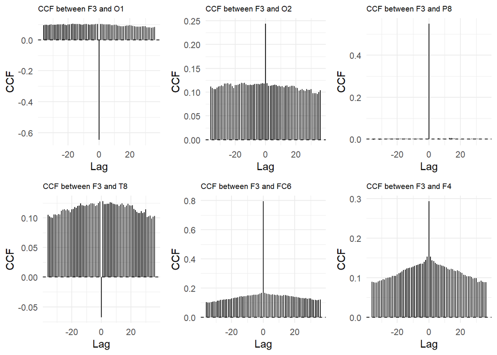

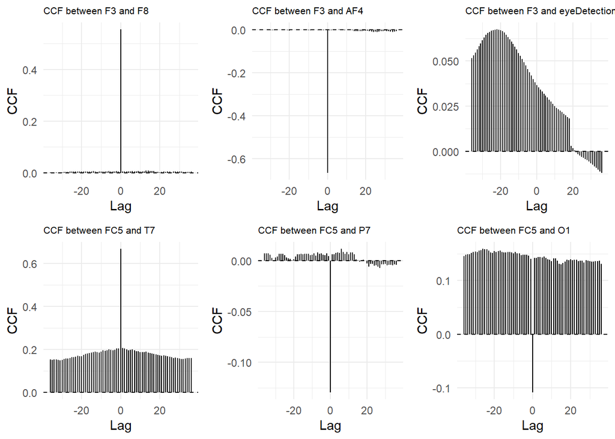

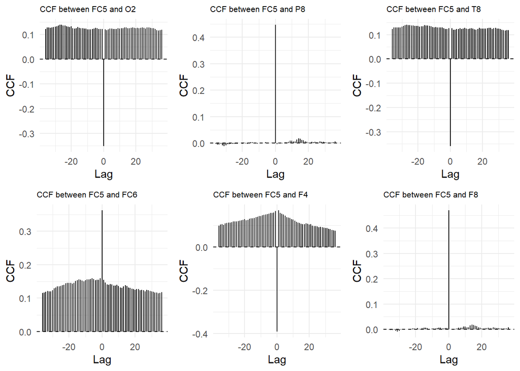

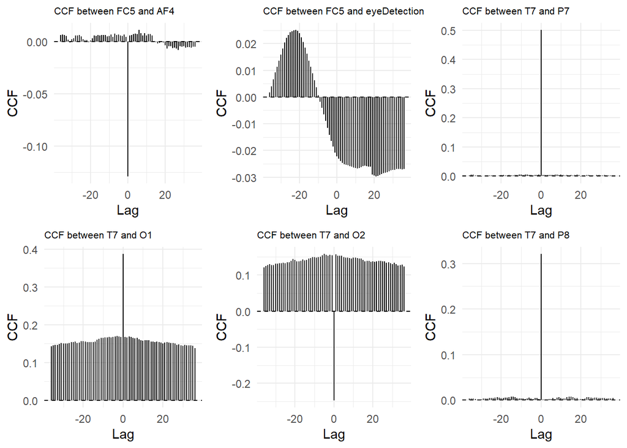

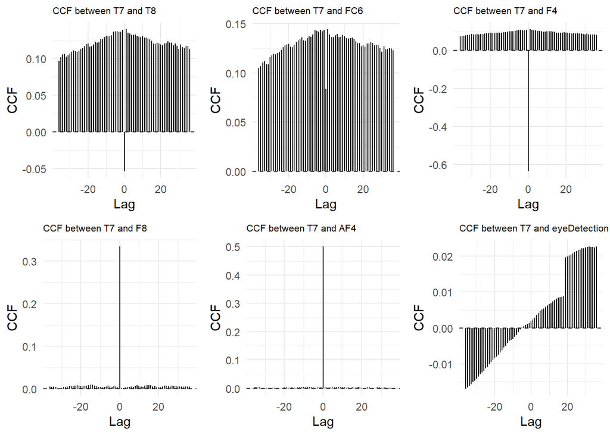

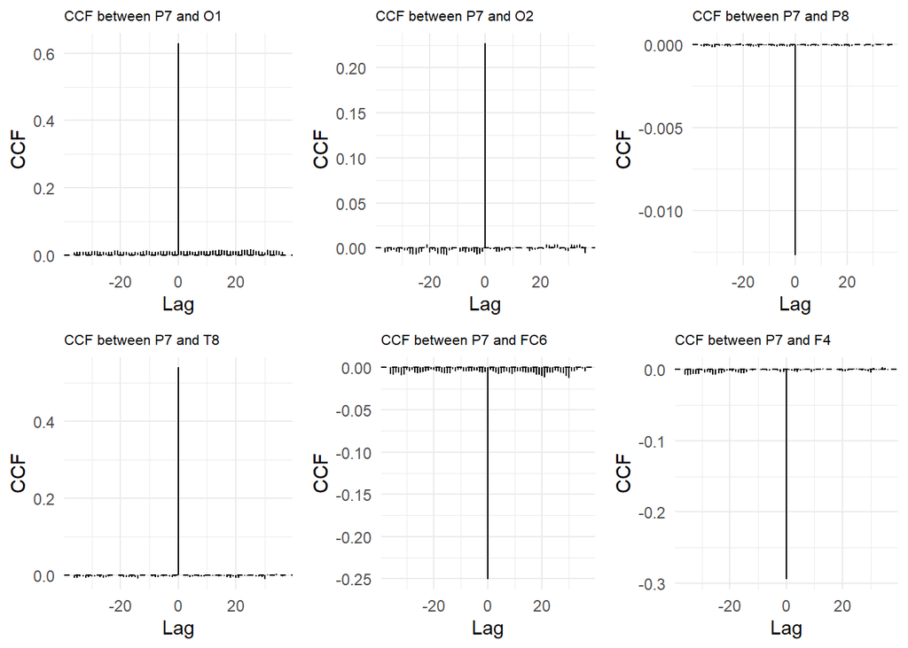

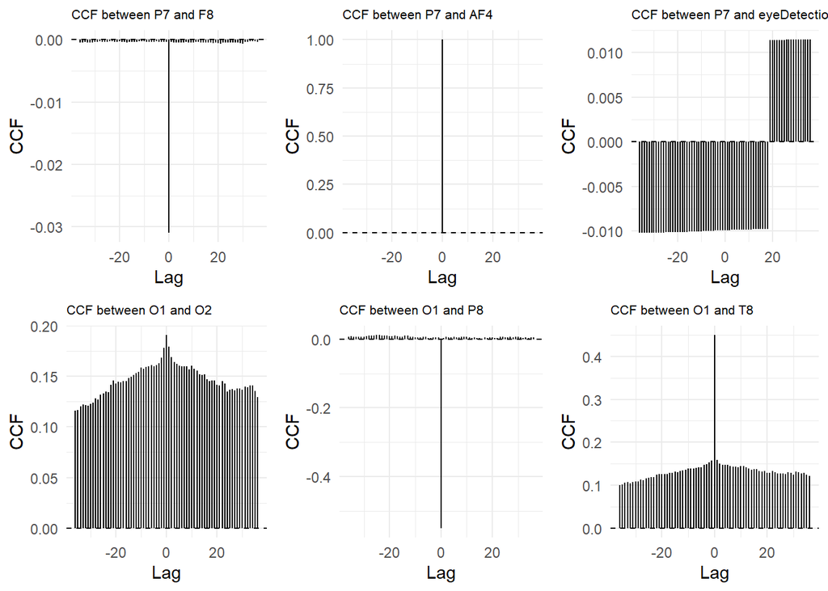

[6 more figures not shown]

```r
library(forecast)
library(ggplot2)
library(dplyr)
library(gridExtra)

# Function to plot cross-correlation
plot_ccf <- function(series1, series2, series1_name, series2_name) {
  ccf_result <- ccf(series1, series2, plot = FALSE)
  ccf_data <- data.frame(
    lag = ccf_result$lag,
    acf = ccf_result$acf
  )
  ggplot(ccf_data, aes(x = lag, y = acf)) +
    geom_hline(yintercept = 0, linetype = "dashed") +
    geom_segment(aes(xend = lag, yend = 0)) +
    labs(
      title = paste("CCF between", series1_name, "and", series2_name),
      x = "Lag",
      y = "CCF"
    ) +
    theme_minimal() +
    theme(plot.title = element_text(size = 8))  # Adjust title size here
}

# Select columns and remove 'ds'
eeg_data <- eeg_train %>% select(-ds)

# Create pairs of columns
colnames <- colnames(eeg_data)
pairs <- combn(colnames, 2, simplify = FALSE)

# Plot cross-correlation for each pair
plots <- lapply(pairs, function(pair) {
  series1_name <- pair[1]
  series2_name <- pair[2]
  series1 <- eeg_data[[series1_name]]
  series2 <- eeg_data[[series2_name]]
  plot_ccf(series1, series2, series1_name, series2_name)
})

# Print plots in pages of 6
plot_pages <- split(plots, ceiling(seq_along(plots)/6))

for (page in plot_pages) {
  do.call("grid.arrange", c(page, ncol = 3, nrow = 2))
}
```

#### Frequency-Space

We can also explore the data in frequency space by using a Fast Fourier Transform.  
After the FFT we can summarise the distributions of frequencies by their density across the power spectrum. This will let us see if there any obvious patterns related to eye status in the overall frequency distributions.

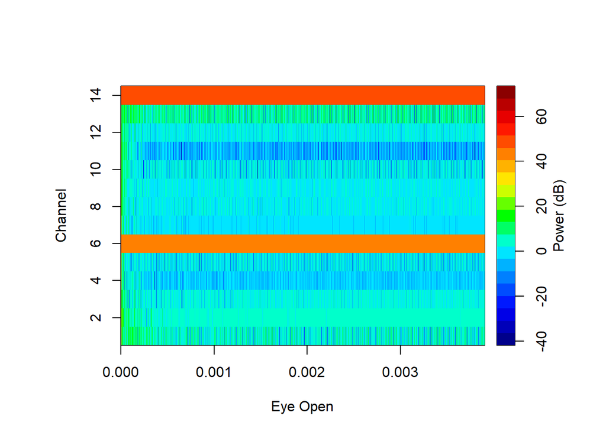

```r
eegkit::eegpsd(eeg_train %>% dplyr::filter(eyeDetection == 0) %>% dplyr::select(-eyeDetection, -ds), Fs = Fs, xlab="Eye Open")
```

*Note*: Just wondering if the coding may be slightly wrong for this? Isn’t the x-axis supposed to potentially demonstrate frequency in something like Hertz? Maybe something like below?

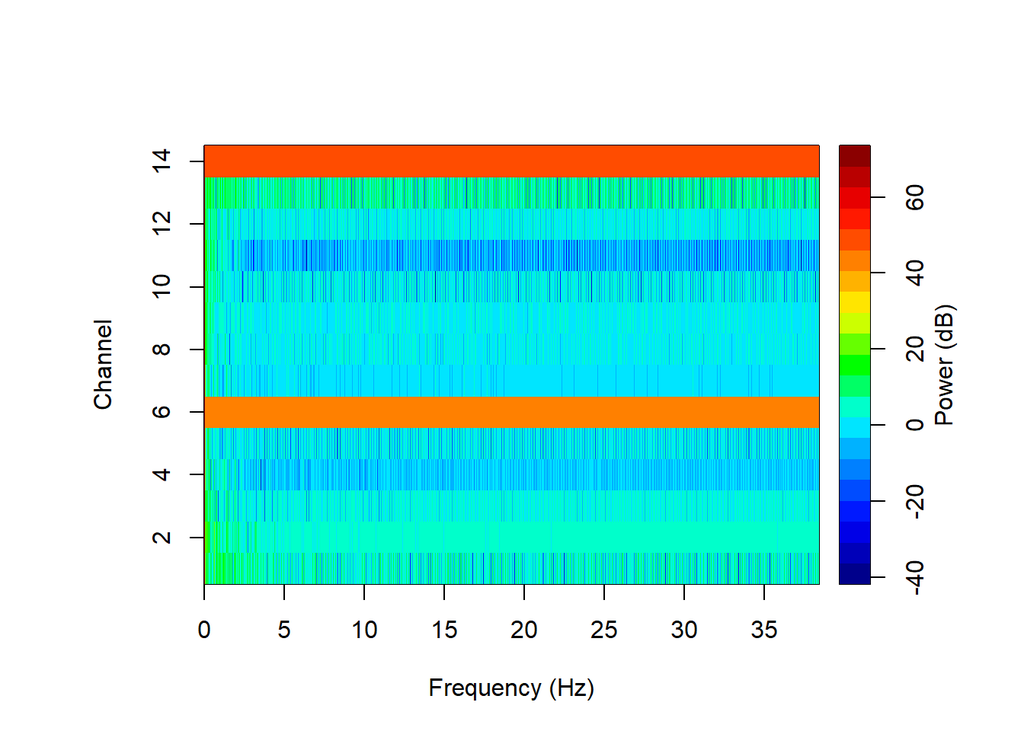

```r
# Load required libraries
library(eegkit)
library(dplyr)
library(ggplot2)
library(gridExtra)

# Assuming eeg_train is already loaded
# Calculate sampling rate Fs (samples per second)
num_samples <- nrow(eeg_train)
total_duration <- 117  # seconds
Fs <- num_samples / total_duration

# Function to plot EEG PSD with ggplot2
plot_eeg_psd <- function(eeg_data, eye_status, Fs) {
  # Calculate the power spectral density
  psd_result <- eegkit::eegpsd(eeg_data, Fs = Fs)

  # Create a data frame from the psd_result
  psd_data <- data.frame(
    Frequency = psd_result$freq,
    Power = psd_result$spec
  )

  # Generate the plot using ggplot2
  p <- ggplot(psd_data, aes(x = Frequency, y = Power)) +
    geom_line() +
    labs(
      x = "Frequency (Hz)",
      y = "Power"
    ) +
    ggtitle(ifelse(eye_status == 0, "Eyes Open", "Eyes Closed")) +  # Title based on eye_status
    theme_minimal() +
    theme(plot.title = element_text(hjust = 0.5, size = 10))  # Center and resize the title

  return(p)
}

# Filter data for eyes open and closed
eeg_open <- eeg_train %>% filter(eyeDetection == 0) %>% select(-eyeDetection, -ds)
eeg_closed <- eeg_train %>% filter(eyeDetection == 1) %>% select(-eyeDetection, -ds)

# Plot EEG Power Spectral Density (PSD) for eyes open and closed
psd_open <- plot_eeg_psd(eeg_open, 0, Fs)
```

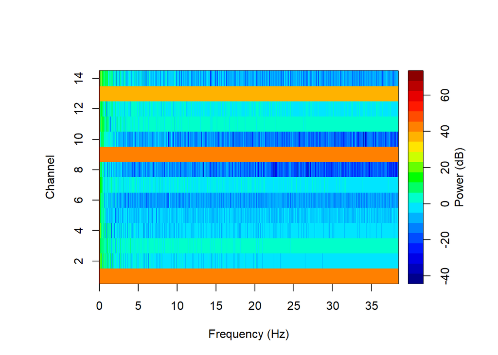

```r
psd_closed <- plot_eeg_psd(eeg_closed, 1, Fs)
```

```r
# Add titles directly in each plot
psd_open <- psd_open +
  labs(title = "Eyes Open")

psd_closed <- psd_closed +
  labs(title = "Eyes Closed")
```

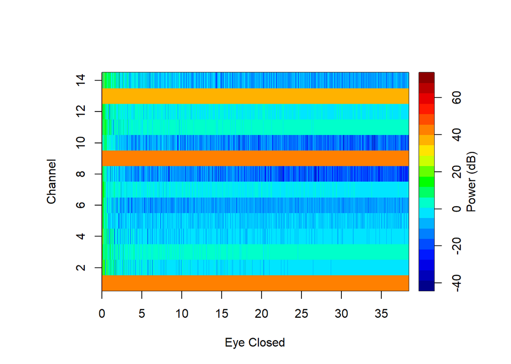

```r
eegkit::eegpsd(eeg_train %>% dplyr::filter(eyeDetection == 1) %>% dplyr::select(-eyeDetection, -ds), Fs = Fs, xlab="Eye Closed")
```

**8** Do you see any differences between the power spectral densities for the two eye states? If so, describe them.